# UDACITY DATA ANALYSIS NANODEGREES

## Project III - Visualizing FordGoBike Data

```
  By Johnson Joseph
```

## Dataset Overview

Bay Wheels is a regional public bicycle sharing system in the San Francisco Bay Area, California operated by Motivate (a company based in New York City that operates bicycle sharing systems in the United States), in a partnership with the Metropolitan Transportation Commission and the Bay Area Air Quality Management District.

After Motivate's acquisition by Lyft, the system was subsequently renamed to Bay Wheels in June 2019.[5] The system is expected to expand to 7,000 bicycles around 540 stations in San Francisco, Oakland, Berkeley, Emeryville, and San Jose. Bay Wheels is the first regional and large-scale bicycle sharing system deployed in California and on the West Coast of the United States.

The data consists of information regarding over 3 million bike rides from January 2018 to July 2019. Including start details, end details and anonymised user details.

## Distribution of Bike Trips, by Age Category

This confirms that age between 26 and 35 take more trips

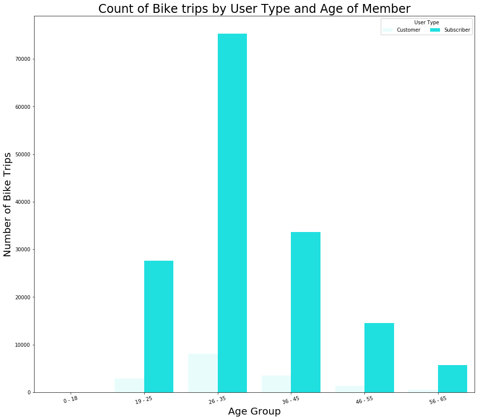